# (Flights Dataset Exploration Presentation)

## by (Abdelrahman Nasr)

## Investigation Overview

> Describe the carrier feature effect on the numbers of delayed, canceled and diverted flights.

## Dataset Overview

> There are 159335 flights information in the dataset with each entry lists the number of flights, the number of flights delayed, the number of flights canceled and diverted, the minutes of delay due to (carrier-weather-national air system-security) and finally the sum of total delay minutes.

## (Visualization 1)

> First visual shows The percentage of the number of delayed and diverted flights to the total number of arrived flights for each carrier and it's clear that the JetBlue Airways carrier (B6) has the highest proportion of delayed flights while Hawaiian Airlines Inc. carrier has the lowest proportion.

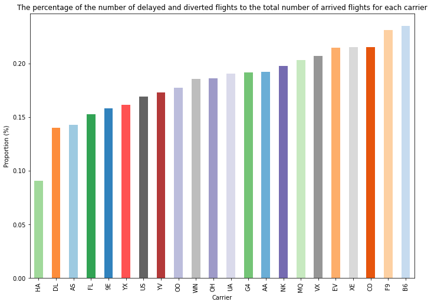

## (Visualization 2)

> Second visual shows the proportion between the number of canceled flights to the total number of arrived flights for each carrier and it's clear that the Allegiant Air carrier (G4) has the hightest proportions in canceled flights while Hawaiian Airlines Inc. carrier has the lowest proportion.

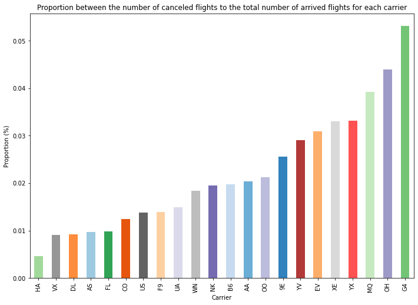

## (Visualization 3)

> Thired visual shows the Proportion between the total time of delay to the counts of delayed flights for each reason to calculate the mean delay time for each reason and as you can see the weather has the highest mean while security has the lowest.

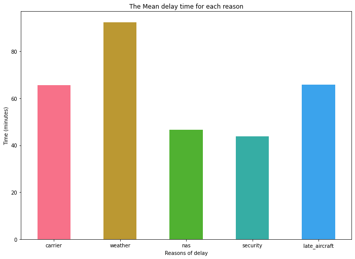

## (Visualization 4)

> Fourth visual shows Proportion between the total time of delay to the counts of delayed flights for each reason grouped by each carrier to calculate the mean delay time for each reason for each carrier.

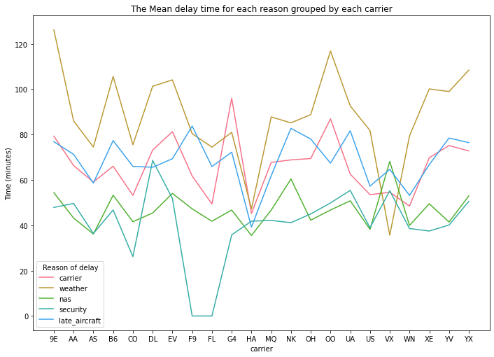